# Charity Donors Prediction

In this project we will predict the chances of a certain person donating to CharityML.

# Importing required libraries

```python
import pandas as pd
import numpy as np
import matplotlib.pyplot as plt
import seaborn as sns
%matplotlib inline
```

# Importing our data

```python
data=pd.read_csv('census.csv')
```

```python
data.head()
```

|  | age | workclass | education_level | education-num | marital-status | occupation | relationship | race | sex | capital-gain | capital-loss | hours-per-week | native-country | income |
| --- | --- | --- | --- | --- | --- | --- | --- | --- | --- | --- | --- | --- | --- | --- |
| 0 | 39 | State-gov | Bachelors | 13.0 | Never-married | Adm-clerical | Not-in-family | White | Male | 2174.0 | 0.0 | 40.0 | United-States | <=50K |
| 1 | 50 | Self-emp-not-inc | Bachelors | 13.0 | Married-civ-spouse | Exec-managerial | Husband | White | Male | 0.0 | 0.0 | 13.0 | United-States | <=50K |
| 2 | 38 | Private | HS-grad | 9.0 | Divorced | Handlers-cleaners | Not-in-family | White | Male | 0.0 | 0.0 | 40.0 | United-States | <=50K |
| 3 | 53 | Private | 11th | 7.0 | Married-civ-spouse | Handlers-cleaners | Husband | Black | Male | 0.0 | 0.0 | 40.0 | United-States | <=50K |
| 4 | 28 | Private | Bachelors | 13.0 | Married-civ-spouse | Prof-specialty | Wife | Black | Female | 0.0 | 0.0 | 40.0 | Cuba | <=50K |

# Checking for null values

```python
data.isnull().sum()
```

```
age                0
workclass          0
education_level    0
education-num      0
marital-status     0
occupation         0
relationship       0
race               0
sex                0
capital-gain       0
capital-loss       0
hours-per-week     0
native-country     0
income             0
dtype: int64
```

So, there are no null values.

# Finding relation between different features and our target_variable

Target variable is income.

Relation between age and income.

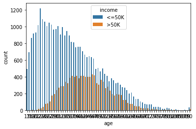

```python
sns.countplot(x='age',hue='income',data=data)
```

We can see that the number of people earning 50K or less decreases with the increase in age.

Relation between workclass and income.

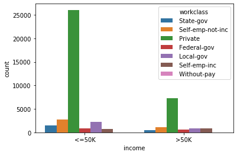

```python
sns.countplot(x='income',hue='workclass',data=data)
```

We can see that the majority of people who earn less than 50K work in private sector.

Relation between education level and income.

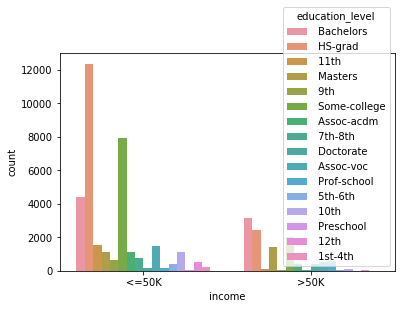

```python
sns.countplot(x='income',hue='education_level',data=data)
```

Relation between marital status and income.

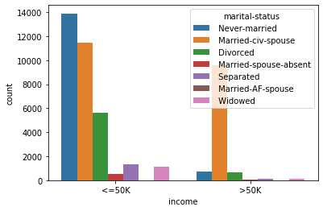

```python
sns.countplot(x='income',hue='marital-status',data=data)
```

We see that the majority of people earning more than 50K are married.

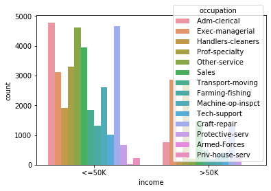

```python
sns.countplot(x='income',hue='occupation',data=data)
```

This graphs does not help us in drawing useful conclusions.

Relation between relationship and income.

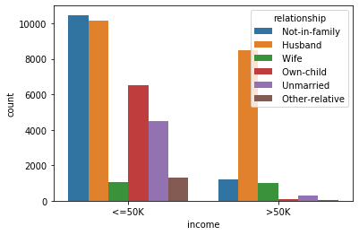

```python
sns.countplot(x='income',hue='relationship',data=data)
```

We can conclude that most of the people with income more than 50K are married and are male.

Relation between race and income.

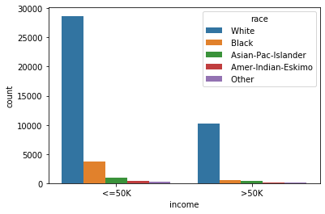

```python
sns.countplot(x='income',hue='race',data=data)
```

Most of the earners with income more than 50K are white.

Relation between sex and income.

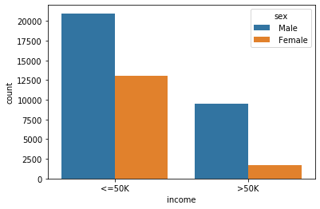

```python
sns.countplot(x='income',hue='sex',data=data)
```

Most of the earners with income more than 50K are male.

# Converting categorical data into indicator data

```python
data.head()
```

|  | age | workclass | education_level | education-num | marital-status | occupation | relationship | race | sex | capital-gain | capital-loss | hours-per-week | native-country | income |
| --- | --- | --- | --- | --- | --- | --- | --- | --- | --- | --- | --- | --- | --- | --- |
| 0 | 39 | State-gov | Bachelors | 13.0 | Never-married | Adm-clerical | Not-in-family | White | Male | 2174.0 | 0.0 | 40.0 | United-States | <=50K |
| 1 | 50 | Self-emp-not-inc | Bachelors | 13.0 | Married-civ-spouse | Exec-managerial | Husband | White | Male | 0.0 | 0.0 | 13.0 | United-States | <=50K |
| 2 | 38 | Private | HS-grad | 9.0 | Divorced | Handlers-cleaners | Not-in-family | White | Male | 0.0 | 0.0 | 40.0 | United-States | <=50K |
| 3 | 53 | Private | 11th | 7.0 | Married-civ-spouse | Handlers-cleaners | Husband | Black | Male | 0.0 | 0.0 | 40.0 | United-States | <=50K |
| 4 | 28 | Private | Bachelors | 13.0 | Married-civ-spouse | Prof-specialty | Wife | Black | Female | 0.0 | 0.0 | 40.0 | Cuba | <=50K |

```python
marital_status=pd.get_dummies(data['marital-status'],drop_first=True)
relationship=pd.get_dummies(data['relationship'],drop_first=True)
race=pd.get_dummies(data['race'],drop_first=True)
sex=pd.get_dummies(data['sex'],drop_first=True)
```

Concatinating this data into our main dataframe.

```python
data=pd.concat([data,marital_status,relationship,race,sex],axis=1)
data.head()
```

|  | age | workclass | education_level | education-num | marital-status | occupation | relationship | race | sex | capital-gain | ... | Not-in-family | Other-relative | Own-child | Unmarried | Wife | Asian-Pac-Islander | Black | Other | White | Male |
| --- | --- | --- | --- | --- | --- | --- | --- | --- | --- | --- | --- | --- | --- | --- | --- | --- | --- | --- | --- | --- | --- |
| 0 | 39 | State-gov | Bachelors | 13.0 | Never-married | Adm-clerical | Not-in-family | White | Male | 2174.0 | ... | 1 | 0 | 0 | 0 | 0 | 0 | 0 | 0 | 1 | 1 |
| 1 | 50 | Self-emp-not-inc | Bachelors | 13.0 | Married-civ-spouse | Exec-managerial | Husband | White | Male | 0.0 | ... | 0 | 0 | 0 | 0 | 0 | 0 | 0 | 0 | 1 | 1 |
| 2 | 38 | Private | HS-grad | 9.0 | Divorced | Handlers-cleaners | Not-in-family | White | Male | 0.0 | ... | 1 | 0 | 0 | 0 | 0 | 0 | 0 | 0 | 1 | 1 |
| 3 | 53 | Private | 11th | 7.0 | Married-civ-spouse | Handlers-cleaners | Husband | Black | Male | 0.0 | ... | 0 | 0 | 0 | 0 | 0 | 0 | 1 | 0 | 0 | 1 |
| 4 | 28 | Private | Bachelors | 13.0 | Married-civ-spouse | Prof-specialty | Wife | Black | Female | 0.0 | ... | 0 | 0 | 0 | 0 | 1 | 0 | 1 | 0 | 0 | 0 |

5 rows × 30 columns

```python
workclass=pd.get_dummies(data['workclass'],drop_first=True)
```

```python
data=pd.concat([data,workclass],axis=1)
data.head()
```

|  | age | workclass | education_level | education-num | marital-status | occupation | relationship | race | sex | capital-gain | ... | Black | Other | White | Male | Local-gov | Private | Self-emp-inc | Self-emp-not-inc | State-gov | Without-pay |
| --- | --- | --- | --- | --- | --- | --- | --- | --- | --- | --- | --- | --- | --- | --- | --- | --- | --- | --- | --- | --- | --- |
| 0 | 39 | State-gov | Bachelors | 13.0 | Never-married | Adm-clerical | Not-in-family | White | Male | 2174.0 | ... | 0 | 0 | 1 | 1 | 0 | 0 | 0 | 0 | 1 | 0 |
| 1 | 50 | Self-emp-not-inc | Bachelors | 13.0 | Married-civ-spouse | Exec-managerial | Husband | White | Male | 0.0 | ... | 0 | 0 | 1 | 1 | 0 | 0 | 0 | 1 | 0 | 0 |
| 2 | 38 | Private | HS-grad | 9.0 | Divorced | Handlers-cleaners | Not-in-family | White | Male | 0.0 | ... | 0 | 0 | 1 | 1 | 0 | 1 | 0 | 0 | 0 | 0 |
| 3 | 53 | Private | 11th | 7.0 | Married-civ-spouse | Handlers-cleaners | Husband | Black | Male | 0.0 | ... | 1 | 0 | 0 | 1 | 0 | 1 | 0 | 0 | 0 | 0 |
| 4 | 28 | Private | Bachelors | 13.0 | Married-civ-spouse | Prof-specialty | Wife | Black | Female | 0.0 | ... | 1 | 0 | 0 | 0 | 0 | 1 | 0 | 0 | 0 | 0 |

5 rows × 36 columns

# Separating our required features

```python
data.drop(['workclass','education_level','education-num','marital-status','occupation','relationship','race','sex'],axis=1,inplace=True)
```

```python
data.head()
```

|  | age | capital-gain | capital-loss | hours-per-week | native-country | income | Married-AF-spouse | Married-civ-spouse | Married-spouse-absent | Never-married | ... | Black | Other | White | Male | Local-gov | Private | Self-emp-inc | Self-emp-not-inc | State-gov | Without-pay |
| --- | --- | --- | --- | --- | --- | --- | --- | --- | --- | --- | --- | --- | --- | --- | --- | --- | --- | --- | --- | --- | --- |
| 0 | 39 | 2174.0 | 0.0 | 40.0 | United-States | <=50K | 0 | 0 | 0 | 1 | ... | 0 | 0 | 1 | 1 | 0 | 0 | 0 | 0 | 1 | 0 |
| 1 | 50 | 0.0 | 0.0 | 13.0 | United-States | <=50K | 0 | 1 | 0 | 0 | ... | 0 | 0 | 1 | 1 | 0 | 0 | 0 | 1 | 0 | 0 |
| 2 | 38 | 0.0 | 0.0 | 40.0 | United-States | <=50K | 0 | 0 | 0 | 0 | ... | 0 | 0 | 1 | 1 | 0 | 1 | 0 | 0 | 0 | 0 |
| 3 | 53 | 0.0 | 0.0 | 40.0 | United-States | <=50K | 0 | 1 | 0 | 0 | ... | 1 | 0 | 0 | 1 | 0 | 1 | 0 | 0 | 0 | 0 |
| 4 | 28 | 0.0 | 0.0 | 40.0 | Cuba | <=50K | 0 | 1 | 0 | 0 | ... | 1 | 0 | 0 | 0 | 0 | 1 | 0 | 0 | 0 | 0 |

5 rows × 28 columns

```python
data.drop('native-country',axis=1,inplace=True)
```

```python
data.head()
```

|  | age | capital-gain | capital-loss | hours-per-week | income | Married-AF-spouse | Married-civ-spouse | Married-spouse-absent | Never-married | Separated | ... | Black | Other | White | Male | Local-gov | Private | Self-emp-inc | Self-emp-not-inc | State-gov | Without-pay |
| --- | --- | --- | --- | --- | --- | --- | --- | --- | --- | --- | --- | --- | --- | --- | --- | --- | --- | --- | --- | --- | --- |
| 0 | 39 | 2174.0 | 0.0 | 40.0 | <=50K | 0 | 0 | 0 | 1 | 0 | ... | 0 | 0 | 1 | 1 | 0 | 0 | 0 | 0 | 1 | 0 |
| 1 | 50 | 0.0 | 0.0 | 13.0 | <=50K | 0 | 1 | 0 | 0 | 0 | ... | 0 | 0 | 1 | 1 | 0 | 0 | 0 | 1 | 0 | 0 |
| 2 | 38 | 0.0 | 0.0 | 40.0 | <=50K | 0 | 0 | 0 | 0 | 0 | ... | 0 | 0 | 1 | 1 | 0 | 1 | 0 | 0 | 0 | 0 |
| 3 | 53 | 0.0 | 0.0 | 40.0 | <=50K | 0 | 1 | 0 | 0 | 0 | ... | 1 | 0 | 0 | 1 | 0 | 1 | 0 | 0 | 0 | 0 |
| 4 | 28 | 0.0 | 0.0 | 40.0 | <=50K | 0 | 1 | 0 | 0 | 0 | ... | 1 | 0 | 0 | 0 | 0 | 1 | 0 | 0 | 0 | 0 |

5 rows × 27 columns

```python
data.drop('hours-per-week',axis=1,inplace=True)
```

```python
data.head()
```

|  | age | capital-gain | capital-loss | income | Married-AF-spouse | Married-civ-spouse | Married-spouse-absent | Never-married | Separated | Widowed | ... | Black | Other | White | Male | Local-gov | Private | Self-emp-inc | Self-emp-not-inc | State-gov | Without-pay |
| --- | --- | --- | --- | --- | --- | --- | --- | --- | --- | --- | --- | --- | --- | --- | --- | --- | --- | --- | --- | --- | --- |
| 0 | 39 | 2174.0 | 0.0 | <=50K | 0 | 0 | 0 | 1 | 0 | 0 | ... | 0 | 0 | 1 | 1 | 0 | 0 | 0 | 0 | 1 | 0 |
| 1 | 50 | 0.0 | 0.0 | <=50K | 0 | 1 | 0 | 0 | 0 | 0 | ... | 0 | 0 | 1 | 1 | 0 | 0 | 0 | 1 | 0 | 0 |
| 2 | 38 | 0.0 | 0.0 | <=50K | 0 | 0 | 0 | 0 | 0 | 0 | ... | 0 | 0 | 1 | 1 | 0 | 1 | 0 | 0 | 0 | 0 |
| 3 | 53 | 0.0 | 0.0 | <=50K | 0 | 1 | 0 | 0 | 0 | 0 | ... | 1 | 0 | 0 | 1 | 0 | 1 | 0 | 0 | 0 | 0 |
| 4 | 28 | 0.0 | 0.0 | <=50K | 0 | 1 | 0 | 0 | 0 | 0 | ... | 1 | 0 | 0 | 0 | 0 | 1 | 0 | 0 | 0 | 0 |

5 rows × 26 columns

# Checking the relation between profit and income

```python
def profit(cols):
    gain=cols[0]
    loss=cols[1]

    return gain-loss
```

```python
data['profit']=data[['capital-gain','capital-loss']].apply(profit,axis=1)
data.head()
```

|  | age | capital-gain | capital-loss | income | Married-AF-spouse | Married-civ-spouse | Married-spouse-absent | Never-married | Separated | Widowed | ... | Other | White | Male | Local-gov | Private | Self-emp-inc | Self-emp-not-inc | State-gov | Without-pay | profit |
| --- | --- | --- | --- | --- | --- | --- | --- | --- | --- | --- | --- | --- | --- | --- | --- | --- | --- | --- | --- | --- | --- |
| 0 | 39 | 2174.0 | 0.0 | <=50K | 0 | 0 | 0 | 1 | 0 | 0 | ... | 0 | 1 | 1 | 0 | 0 | 0 | 0 | 1 | 0 | 2174.0 |
| 1 | 50 | 0.0 | 0.0 | <=50K | 0 | 1 | 0 | 0 | 0 | 0 | ... | 0 | 1 | 1 | 0 | 0 | 0 | 1 | 0 | 0 | 0.0 |
| 2 | 38 | 0.0 | 0.0 | <=50K | 0 | 0 | 0 | 0 | 0 | 0 | ... | 0 | 1 | 1 | 0 | 1 | 0 | 0 | 0 | 0 | 0.0 |
| 3 | 53 | 0.0 | 0.0 | <=50K | 0 | 1 | 0 | 0 | 0 | 0 | ... | 0 | 0 | 1 | 0 | 1 | 0 | 0 | 0 | 0 | 0.0 |
| 4 | 28 | 0.0 | 0.0 | <=50K | 0 | 1 | 0 | 0 | 0 | 0 | ... | 0 | 0 | 0 | 0 | 1 | 0 | 0 | 0 | 0 | 0.0 |

5 rows × 27 columns

[figure not shown]

```python
sns.countplot(x='profit',hue='income',data=data)
```

[figure not shown]

```python
sns.countplot(x='capital-gain',hue='income',data=data)
```

As this is of no use.Therefore, we will be dropping capital-gain and capital loss.

```python
data.drop(['capital-gain','capital-loss'],axis=1,inplace=True)
```

```python
data.head()
```

|  | age | income | Married-AF-spouse | Married-civ-spouse | Married-spouse-absent | Never-married | Separated | Widowed | Not-in-family | Other-relative | ... | Other | White | Male | Local-gov | Private | Self-emp-inc | Self-emp-not-inc | State-gov | Without-pay | profit |
| --- | --- | --- | --- | --- | --- | --- | --- | --- | --- | --- | --- | --- | --- | --- | --- | --- | --- | --- | --- | --- | --- |
| 0 | 39 | <=50K | 0 | 0 | 0 | 1 | 0 | 0 | 1 | 0 | ... | 0 | 1 | 1 | 0 | 0 | 0 | 0 | 1 | 0 | 2174.0 |
| 1 | 50 | <=50K | 0 | 1 | 0 | 0 | 0 | 0 | 0 | 0 | ... | 0 | 1 | 1 | 0 | 0 | 0 | 1 | 0 | 0 | 0.0 |
| 2 | 38 | <=50K | 0 | 0 | 0 | 0 | 0 | 0 | 1 | 0 | ... | 0 | 1 | 1 | 0 | 1 | 0 | 0 | 0 | 0 | 0.0 |
| 3 | 53 | <=50K | 0 | 1 | 0 | 0 | 0 | 0 | 0 | 0 | ... | 0 | 0 | 1 | 0 | 1 | 0 | 0 | 0 | 0 | 0.0 |
| 4 | 28 | <=50K | 0 | 1 | 0 | 0 | 0 | 0 | 0 | 0 | ... | 0 | 0 | 0 | 0 | 1 | 0 | 0 | 0 | 0 | 0.0 |

5 rows × 25 columns

# Converting income column

```python
income=pd.get_dummies(data['income'],drop_first=True)
```

```python
data=pd.concat([data,income],axis=1)
data.head()
```

|  | age | income | Married-AF-spouse | Married-civ-spouse | Married-spouse-absent | Never-married | Separated | Widowed | Not-in-family | Other-relative | ... | White | Male | Local-gov | Private | Self-emp-inc | Self-emp-not-inc | State-gov | Without-pay | profit | >50K |
| --- | --- | --- | --- | --- | --- | --- | --- | --- | --- | --- | --- | --- | --- | --- | --- | --- | --- | --- | --- | --- | --- |
| 0 | 39 | <=50K | 0 | 0 | 0 | 1 | 0 | 0 | 1 | 0 | ... | 1 | 1 | 0 | 0 | 0 | 0 | 1 | 0 | 2174.0 | 0 |
| 1 | 50 | <=50K | 0 | 1 | 0 | 0 | 0 | 0 | 0 | 0 | ... | 1 | 1 | 0 | 0 | 0 | 1 | 0 | 0 | 0.0 | 0 |
| 2 | 38 | <=50K | 0 | 0 | 0 | 0 | 0 | 0 | 1 | 0 | ... | 1 | 1 | 0 | 1 | 0 | 0 | 0 | 0 | 0.0 | 0 |
| 3 | 53 | <=50K | 0 | 1 | 0 | 0 | 0 | 0 | 0 | 0 | ... | 0 | 1 | 0 | 1 | 0 | 0 | 0 | 0 | 0.0 | 0 |
| 4 | 28 | <=50K | 0 | 1 | 0 | 0 | 0 | 0 | 0 | 0 | ... | 0 | 0 | 0 | 1 | 0 | 0 | 0 | 0 | 0.0 | 0 |

5 rows × 26 columns

Dropping income column.

```python
data.drop('income',axis=1,inplace=True)
```

```python
data.head()
```

|  | age | Married-AF-spouse | Married-civ-spouse | Married-spouse-absent | Never-married | Separated | Widowed | Not-in-family | Other-relative | Own-child | ... | White | Male | Local-gov | Private | Self-emp-inc | Self-emp-not-inc | State-gov | Without-pay | profit | >50K |
| --- | --- | --- | --- | --- | --- | --- | --- | --- | --- | --- | --- | --- | --- | --- | --- | --- | --- | --- | --- | --- | --- |
| 0 | 39 | 0 | 0 | 0 | 1 | 0 | 0 | 1 | 0 | 0 | ... | 1 | 1 | 0 | 0 | 0 | 0 | 1 | 0 | 2174.0 | 0 |
| 1 | 50 | 0 | 1 | 0 | 0 | 0 | 0 | 0 | 0 | 0 | ... | 1 | 1 | 0 | 0 | 0 | 1 | 0 | 0 | 0.0 | 0 |
| 2 | 38 | 0 | 0 | 0 | 0 | 0 | 0 | 1 | 0 | 0 | ... | 1 | 1 | 0 | 1 | 0 | 0 | 0 | 0 | 0.0 | 0 |
| 3 | 53 | 0 | 1 | 0 | 0 | 0 | 0 | 0 | 0 | 0 | ... | 0 | 1 | 0 | 1 | 0 | 0 | 0 | 0 | 0.0 | 0 |
| 4 | 28 | 0 | 1 | 0 | 0 | 0 | 0 | 0 | 0 | 0 | ... | 0 | 0 | 0 | 1 | 0 | 0 | 0 | 0 | 0.0 | 0 |

5 rows × 25 columns

# Building our model

Importing required libraries.

```python
from sklearn.tree import DecisionTreeClassifier
classifier=DecisionTreeClassifier()
```

# Training and testing our model

Importing required libraries.

```python
from sklearn.model_selection import train_test_split
```

```python
x=data.drop('>50K',axis=1)
y=data['>50K']
```

Splitting our data.

```python
x_test,x_train,y_test,y_train=train_test_split(x,y,test_size=0.2)
```

```python
classifier.fit(x_train,y_train)
```

```
DecisionTreeClassifier(ccp_alpha=0.0, class_weight=None, criterion='gini',
                       max_depth=None, max_features=None, max_leaf_nodes=None,
                       min_impurity_decrease=0.0, min_impurity_split=None,
                       min_samples_leaf=1, min_samples_split=2,
                       min_weight_fraction_leaf=0.0, presort='deprecated',
                       random_state=None, splitter='best')
```

Predicting from testing set.

```python
test_predictions=classifier.predict(x_test)
```

```python
test_predictions
```

```
array([0, 0, 0, ..., 1, 0, 0], dtype=uint8)
```

# Checking accuracy

```python
from sklearn.metrics import accuracy_score
```

```python
accuracy=accuracy_score(y_test,test_predictions)
accuracy
```

```
0.804848384332587
```

Therefore,we have successfully built our model.